# problem_set_2

Natalia Aristizábal

1/27/2019

### Problem set 2: Single-species models in continuous time

1. Exponential growth in cancer

Imagine you are applying your ecology and evolution knowledge to better understand the development of cancer (a burgeoning new field actually11 Merlo et al., 2006. Cancer as an evolutionary and ecological process. Nature reviews cancer, 6(12), p.924.). After metastasizing, cancer spread throughout the body, a single cancer cell reached the patient’s colon. The cancer cell now divides and grows at an exponential rate. Spratt et. al (1996) found that colon cancer had an average doubling time of 109 days. Assume a lethal cancer size is on the order of 1 x 10 ^12 (1 000 000 000 000) cells.

How long will it take for the colon tumor to reach this lethal size if left untreated?

Helpful reading: Merlo et al., 2006. Cancer as an evolutionary and ecological process. Nature reviews cancer, 6(12), p.924.

$$N_t = N_0{e^{rt}}$$

Using the exponential growth rate rule above, solve for R

$$\frac{N_t}{N_0} = e^{rt}$$

$$\frac{ln(\frac{N_t}{N_0})}{t} = r$$

$$\frac{ln(\frac{2}{1})}{109} = r$$

$$0.006 = r$$

Now use r to find t

$$\frac{ln(\frac{N_t}{N_0})}{r} = t$$

$$\frac{ln(\frac{1 x 10^{12}}{1})}{ 0.006359148} = t$$

$$4345.082 = t$$

So it will take 4,345 days, or about 12 years, for the colon tumor to reach a lethal size, asuming it was left untreated.

2. Sterile insect release

One strategy to combat problematic insect species (like malaria-carrying mosquitoes) is to release sterile males to overwhelm the population. This approach is being used to control Aedes aegypti and Aedes albopictus mosquitoes in the hopes of preventing dengue and yellow fever. The equation below denotes the number of females (F), number of males (M), birth rate (b), and death rate (d). Determine the equilibrium points and the stability of each for the equation.

From
$$\frac{dN}{dt} = b\frac{N}{N+M}-d$$

Find the two equilibrium points, the first one is:

$$N = 0$$

and the second one is:

$$0 = b\frac{N}{N+M}-d$$

$$0 = b\frac{N}{N+M}-d(N + M)$$

$$0 = \frac{bN - dN - dM}{N+M})$$

$$0 = \frac{N(b - d) - dM}{N+M})$$

$$N(b - d) = dM$$

$$N = \frac{dM}{b-d}$$

To find stability, or rate of change, we take the derivative and then susbtitute with N from above:

$$\frac{dN}{dt} = b\frac{N}{N+M}-d$$

$$\frac{bM}{\ (N + M)^2}$$

$$\frac{bM}{\ (\frac{dM}{b-d} + M)^2}$$

$$\frac{bM}{\ (\frac{bM}{b-d})^2}$$

$$\frac{(b-d)^2}{bM}$$

Which equilibrium point tells you the critical threshold for population extinction? How does this relate to the Allee effect?

There are two unstable equilibrium points, but only one makes biological sense, when N = 0, and that one indicates the critical threshold for population extinction. This threshold, is also called an Allele effect, or the point at which the population size will not recuparate and inevitably go extinct.

3. Sterile insect release with competition

The previous problem did not include any negative density-dependence. To test this assumption, we can include competition in our previous problem. Assuming N=0 is an equilbium point (if N=0, it will not change), modify the code below to estimate the two other equilbrium points and each of their stability. If the population drops below 0, assume it went extinct. You can modify both the initial state value for N or the amount of time (times object) to run the model. When you know the equilbrium points and their stability, sketch a plot of $b\frac{N}{N+M}-d-cN$ versus N and show the equilibrium points as open (unstable) or closed (stable) balls.

$$\frac{dN}{dt} = b\frac{N}{N+M}-d-cN$$

Manipulating the initial population state and running different models.

```r
require(deSolve)
```

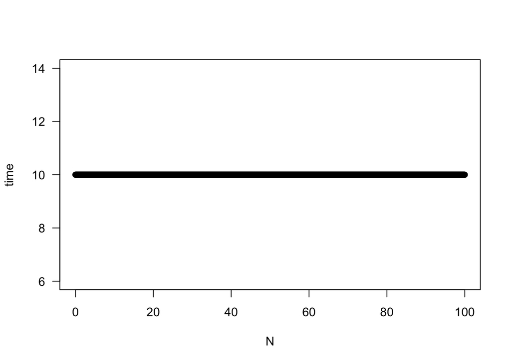

```r
# Initial values: population at 10
state <- c(N = 10)
times <- seq(0, 100, by = 0.1)

# Parameters
parameters <- c(b = 2.4, c = 0.02, M = 50, d = 0.2)

# Model
sterile_insect <- function(t, state, parameters) {
  with(as.list(c(state, parameters)), {
       dN <- b * N / (N + M) - d - c * N
      list(c(dN))
  })}

# Solve model and plot results
out <- ode(y = state, times = times, func = sterile_insect, parms = parameters)
par(mfrow = c(1, 1))
plot(out[ ,1], out[ ,2],
                xlab = 'N',
                ylab = 'time',
                las = 1)
```

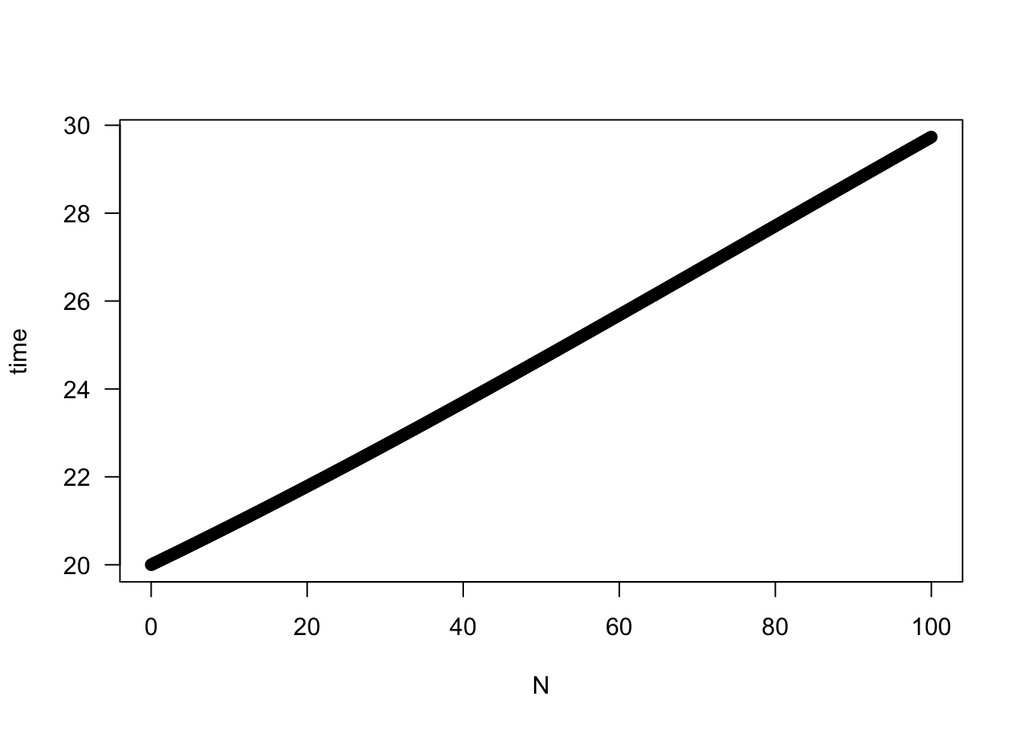

```r
# Initial values: population at 20
state <- c(N = 20)
times <- seq(0, 100, by = 0.1)

# Parameters
parameters <- c(b = 2.4, c = 0.02, M = 50, d = 0.2)

# Model
sterile_insect <- function(t, state, parameters) {
  with(as.list(c(state, parameters)), {
       dN <- b * N / (N + M) - d - c * N
      list(c(dN))
  })}

# Solve model and plot results
out <- ode(y = state, times = times, func = sterile_insect, parms = parameters)
par(mfrow = c(1, 1))
plot(out[ ,1], out[ ,2],
                xlab = 'N',
                ylab = 'time',
                las = 1)
```

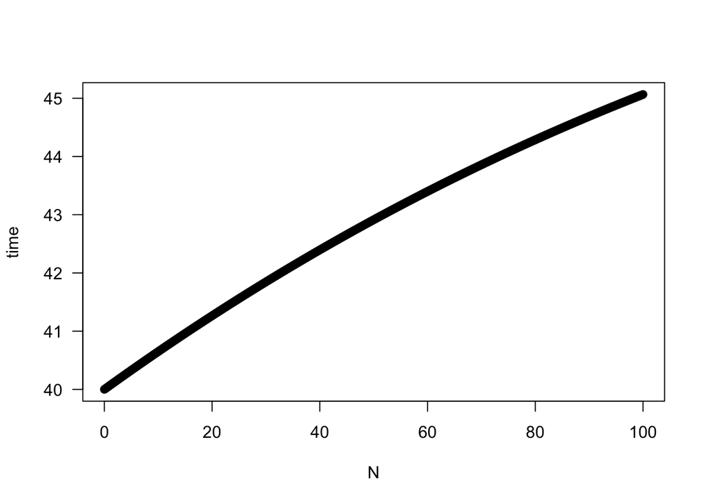

```r
# Initial values: population at 40
state <- c(N = 40)
times <- seq(0, 100, by = 0.1)

# Parameters
parameters <- c(b = 2.4, c = 0.02, M = 50, d = 0.2)

# Model
sterile_insect <- function(t, state, parameters) {
  with(as.list(c(state, parameters)), {
       dN <- b * N / (N + M) - d - c * N
      list(c(dN))
  })}

# Solve model and plot results
out <- ode(y = state, times = times, func = sterile_insect, parms = parameters)
par(mfrow = c(1, 1))
plot(out[ ,1], out[ ,2],
                xlab = 'N',
                ylab = 'time',
                las = 1)
```

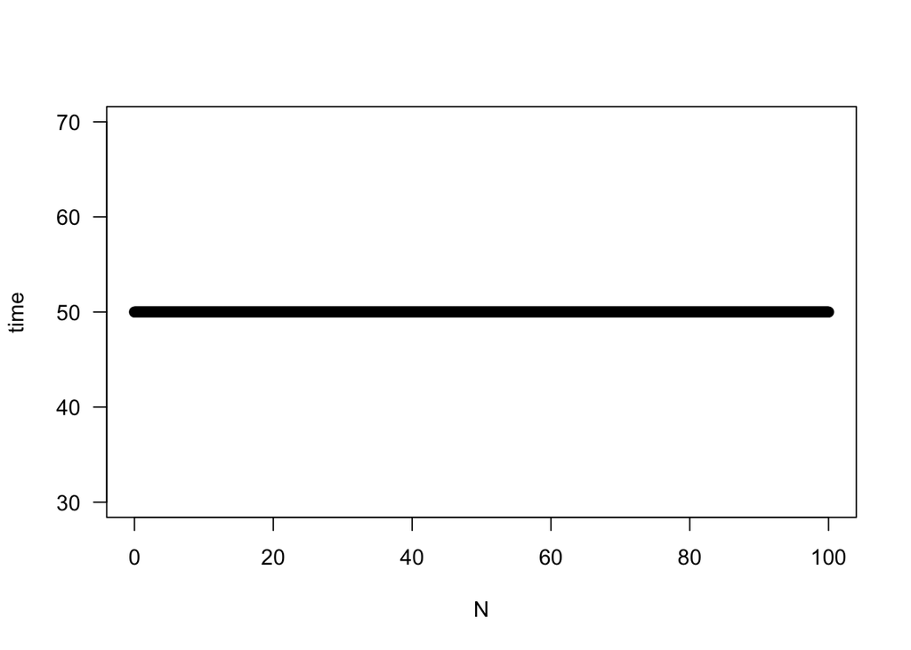

```r
# Initial values: population at 50
state <- c(N = 50)
times <- seq(0, 100, by = 0.1)

# Parameters
parameters <- c(b = 2.4, c = 0.02, M = 50, d = 0.2)

# Model
sterile_insect <- function(t, state, parameters) {
  with(as.list(c(state, parameters)), {
       dN <- b * N / (N + M) - d - c * N
      list(c(dN))
  })}

# Solve model and plot results
out <- ode(y = state, times = times, func = sterile_insect, parms = parameters)
par(mfrow = c(1, 1))
plot(out[ ,1], out[ ,2],
                xlab = 'N',
                ylab = 'time',
                las = 1)
```

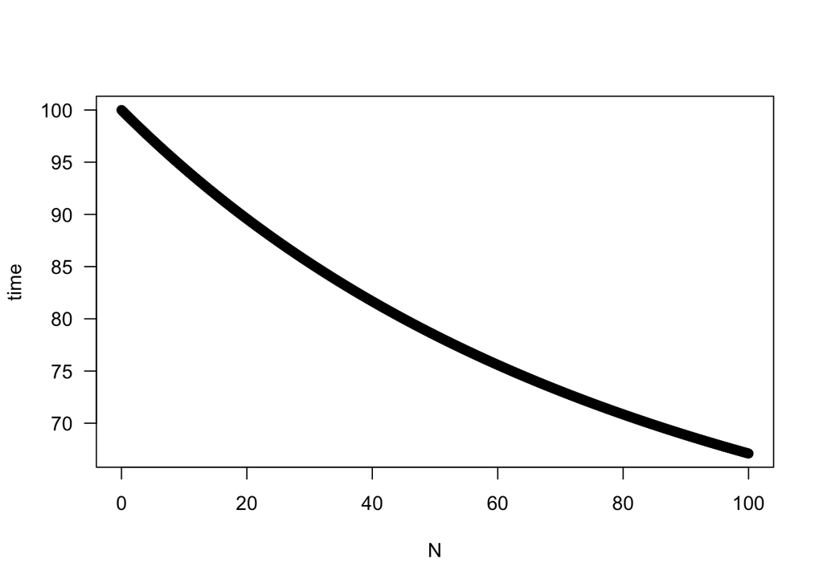

```r
# Initial values: population at 100
state <- c(N = 100)
times <- seq(0, 100, by = 0.1)

# Parameters
parameters <- c(b = 2.4, c = 0.02, M = 50, d = 0.2)

# Model
sterile_insect <- function(t, state, parameters) {
  with(as.list(c(state, parameters)), {
       dN <- b * N / (N + M) - d - c * N
      list(c(dN))
  })}

# Solve model and plot results
out <- ode(y = state, times = times, func = sterile_insect, parms = parameters)
par(mfrow = c(1, 1))
plot(out[ ,1], out[ ,2],
                xlab = 'N',
                ylab = 'time',
                las = 1)
```

Ok. So Equilibrium points = N = 10, N= 50.

I will try to learn for next time how to do this with a loop so that I don’t have to manually change a parameter.

Now plot the equation

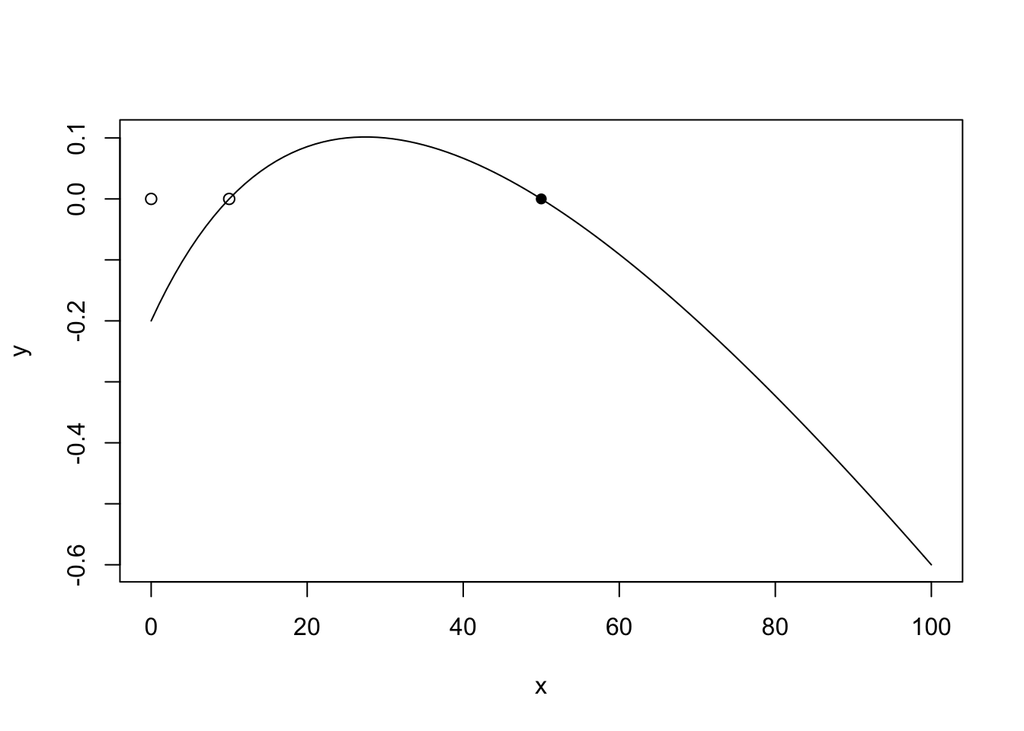

```r
# parameters
b = 2.4
c = 0.02
M = 50
d = 0.2

curve(b * x / (x + M) - d - c * x, from = 0, to = 100, xlab="x", ylab="y")


x <- c(0,10,50)
y <- c(0,0,0)

points(x,y, pch = c(1, 1, 16))
```

Equilibrium points shown as open (unstable) and closed (stable) balls.